# PROJET Deep Learning

### Groupe 14 – Détection automatique de la qualité des œufs

```
    SIDIBE CHEICK ABDRAMANE
    KEI AURIELLE
```

**Dataset :** Good and Bad Eggs Identification Image Dataset  
**Objectif :** Classifier automatiquement les œufs sains et défectueux à partir d’images.

MASTER 2 - IA - UNIVERSITE FELIX HOUPHOUET BOIGNY  
Année académique 2025-2026

### Importation des librairies

```python
import os
import warnings
from pathlib import Path

import numpy as np
import pandas as pd
import cv2
from tqdm.auto import tqdm

import matplotlib.pyplot as plt
import seaborn as sns

from skimage.feature import hog, local_binary_pattern, graycomatrix, graycoprops

from sklearn.model_selection import train_test_split
from sklearn.preprocessing import StandardScaler
from sklearn.decomposition import PCA, FastICA, TruncatedSVD
from sklearn.metrics import accuracy_score, f1_score, confusion_matrix, recall_score

from sklearn.svm import SVC
from sklearn.ensemble import RandomForestClassifier
from sklearn.linear_model import LogisticRegression
from sklearn.neighbors import KNeighborsClassifier
from sklearn.neural_network import MLPClassifier

import torch
import torchvision.models as models
import torchvision.transforms as T
from PIL import Image

try:
    from xgboost import XGBClassifier
    XGBOOST_AVAILABLE = True
except:
    XGBOOST_AVAILABLE = False

try:
    import umap
    UMAP_AVAILABLE = True
except:
    UMAP_AVAILABLE = False

warnings.filterwarnings('ignore')
device = 'cuda' if torch.cuda.is_available() else 'cpu'
RANDOM_STATE = 42
```

## 1. Chargement des données

```python
DATA_ROOT = Path(r'C:\Users\cheic\Documents\M2 IA MathInfo\DeepL\PROJET FINAL DPL')
original_dir = DATA_ROOT / 'Original Images(Eggs)'
aug_dir = DATA_ROOT / 'Augmented_Images(Eggs)'

def gather_paths(base_dir):
    rows = []
    if not base_dir.exists():
        return rows
    for label_dir in ['Good Eggs', 'Bad Eggs']:
        class_path = base_dir / label_dir
        if not class_path.exists():
            continue
        for img_path in class_path.glob('*'):
            if img_path.suffix.lower() in ['.jpg', '.jpeg', '.png', '.bmp']:
                rows.append({
                    'path': str(img_path),
                    'label': 'good' if 'Good' in label_dir else 'bad',
                    'source': base_dir.name
                })
    return rows

# Chargement séparé
df_orig = pd.DataFrame(gather_paths(original_dir))
df_aug = pd.DataFrame(gather_paths(aug_dir))

# Encodage
df_orig['label_enc'] = df_orig['label'].map({'good': 0, 'bad': 1})
df_aug['label_enc'] = df_aug['label'].map({'good': 0, 'bad': 1})

# Split rigoureux train/val/test sur originales uniquement
train_orig, temp = train_test_split(df_orig, test_size=0.3, stratify=df_orig['label_enc'], random_state=RANDOM_STATE)
val_orig, test_orig = train_test_split(temp, test_size=0.5, stratify=temp['label_enc'], random_state=RANDOM_STATE)

# Ajout des augmentations au train uniquement
df_train = pd.concat([train_orig, df_aug], ignore_index=True)
df_val = val_orig.copy()
df_test = test_orig.copy()

print(f"Train: {len(df_train)}, Validation: {len(df_val)}, Test: {len(df_test)}")
```

```
Train: 6700, Validation: 150, Test: 150
```

Description du jeu de données

Le dataset est composé de deux catégories :

- Œufs sains (Good)
- Œufs défectueux (Bad)

Il contient :

- 1000 images originales
- 6000 images augmentées artificiellement

Dans notre méthodologie, les images originales sont utilisées comme base de référence, tandis que les images augmentées servent à améliorer la robustesse du modèle lors de l’entraînement.

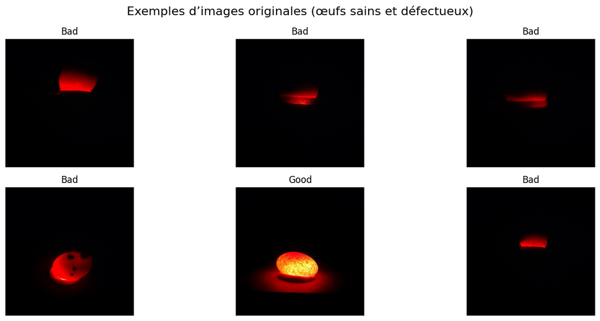

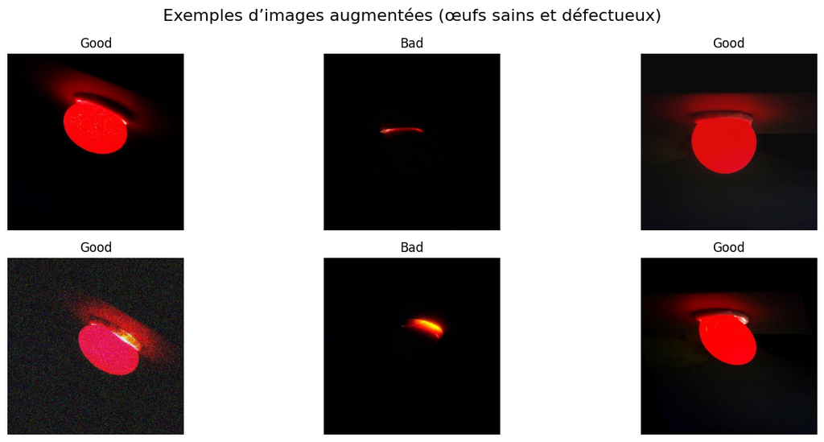

```python
import random

def show_samples(df, title, n_samples=6):
    samples = df.sample(n_samples, random_state=RANDOM_STATE)

    plt.figure(figsize=(14, 6))
    for i, (_, row) in enumerate(samples.iterrows()):
        img = cv2.imread(row["path"])
        img = cv2.cvtColor(img, cv2.COLOR_BGR2RGB)

        plt.subplot(2, n_samples // 2, i + 1)
        plt.imshow(img)
        plt.title(f"{row['label'].capitalize()}")
        plt.axis("off")

    plt.suptitle(title, fontsize=16)
    plt.tight_layout()
    plt.show()


# Images originales
show_samples(df_orig, "Exemples d’images originales (œufs sains et défectueux)")

# Images augmentées
show_samples(df_aug, "Exemples d’images augmentées (œufs sains et défectueux)")
```

Visualisation d’échantillons du jeu de données

Avant de procéder aux étapes de prétraitement et d’extraction de caractéristiques, il est essentiel d’examiner visuellement quelques échantillons du jeu de données.

Cette visualisation permet de :

- vérifier la qualité des images,
- observer les différences visuelles entre œufs sains et défectueux,
- comparer les images originales et les images issues de l’augmentation de données.

## 2. Prétraitements

```python
def preprocess_image(img_path, target_size=(224,224), apply_clahe=True):
    """Prétraitement uniforme pour toutes les images (classiques et deep)"""
    img = cv2.imread(img_path)
    if img is None:
        return None
    gray = cv2.cvtColor(img, cv2.COLOR_BGR2GRAY)
    gray = cv2.normalize(gray, None, 0, 255, cv2.NORM_MINMAX)
    gray = cv2.medianBlur(gray, 5)
    if apply_clahe:
        clahe = cv2.createCLAHE(clipLimit=2.0, tileGridSize=(8,8))
        gray = clahe.apply(gray)
    gray_resized = cv2.resize(gray, target_size, interpolation=cv2.INTER_AREA)
    return gray_resized.astype(np.float32) / 255.0

def preprocess_image_rgb(img_path, target_size=(224,224)):
    """Prétraitement pour les modèles profonds (RGB)"""
    img_gray = preprocess_image(img_path, target_size=target_size, apply_clahe=True)
    img = cv2.imread(img_path)
    img = cv2.cvtColor(img, cv2.COLOR_BGR2RGB)
    img = cv2.resize(img, target_size)
    img = img.astype(np.float32)/255.0
    return img, img_gray  # retourne RGB et grayscale

print("Prétraitement configuré: normalisation, filtre médian, CLAHE, redimensionnement")
```

```
Prétraitement configuré: normalisation, filtre médian, CLAHE, redimensionnement
```

Les images présentent des variations importantes d’éclairage et de bruit. Afin de rendre l’extraction de caractéristiques plus robuste, nous avons appliqué les étapes suivantes :

- Normalisation de l’intensité lumineuse
- Filtrage médian pour réduire le bruit
- Égalisation adaptative (CLAHE) pour renforcer les fissures
- Redimensionnement uniforme à 224×224

## 3. Extracteurs classiques

HOG – fissures et contours

```python
def extract_hog(img_gray):
    img_uint8 = (img_gray*255).astype(np.uint8)
    return hog(img_uint8, orientations=9, pixels_per_cell=(8,8), cells_per_block=(2,2), feature_vector=True)
```

LBP multi-échelle – texture

```python
def extract_lbp(img_gray):
    img_uint8 = (img_gray*255).astype(np.uint8)
    lbp_features = []
    for radius, n_points in zip([1,2,3],[8,16,24]):
        lbp = local_binary_pattern(img_uint8, n_points, radius, method='uniform')
        hist,_ = np.histogram(lbp.ravel(), bins=np.arange(0,n_points+3), range=(0,n_points+2), density=True)
        lbp_features.extend(hist)
    return np.array(lbp_features)
```

GLCM

```python
def extract_glcm(img_gray):
    img_uint8 = (img_gray*255).astype(np.uint8)
    glcm = graycomatrix(img_uint8, distances=[1,2], angles=[0,np.pi/4,np.pi/2], levels=256, symmetric=True, normed=True)
    features = []
    for prop in ['contrast','homogeneity','energy','correlation']:
        features.extend(graycoprops(glcm, prop).ravel())
    return np.array(features)
```

Moments de Hu – formes irrégulières

```python
def extract_hu_moments(img_gray):
    img_uint8 = (img_gray*255).astype(np.uint8)
    moments = cv2.moments(img_uint8)
    hu = cv2.HuMoments(moments)
    hu = -np.sign(hu) * np.log10(np.abs(hu)+1e-10)
    return hu.flatten()
```

Histogrammes HSV – décoloration

```python
def extract_hsv_histogram(img_path):
    img = cv2.imread(img_path)
    hsv = cv2.cvtColor(img, cv2.COLOR_BGR2HSV)
    hist = cv2.calcHist([hsv],[0,1,2],None,[16,16,16],[0,180,0,256,0,256])
    cv2.normalize(hist,hist)
    return hist.flatten()
```

Extraction globale des caractéristiques

```python
def extract_classical_features(img_path):
    _, img_gray = preprocess_image_rgb(img_path)
    return np.concatenate([
        extract_hog(img_gray),
        extract_lbp(img_gray),
        extract_glcm(img_gray),
        extract_hu_moments(img_gray),
        extract_hsv_histogram(img_path)
    ])

print("Extracteurs classiques: HOG, LBP, GLCM, Hu, HSV")
```

```
Extracteurs classiques: HOG, LBP, GLCM, Hu, HSV
```

Les descripteurs classiques permettent de capturer des motifs locaux liés à la texture et à la forme des défauts.

Nous utilisons :

- HOG pour les contours
- LBP pour la texture
- GLCM pour la rugosité
- Moments de Hu pour la forme
- Histogrammes HSV pour la couleur

## 4. Extracteurs profonds

```python
#Transformations ImageNet
transform_imagenet = T.Compose([
    T.Resize((224, 224)),
    T.ToTensor(),
    T.Normalize(
        mean=[0.485, 0.456, 0.406],
        std=[0.229, 0.224, 0.225]
    )
])

#chargement image RGB
def load_image_tensor(path):
    img = Image.open(path).convert('RGB')
    return transform_imagenet(img).unsqueeze(0)
```

EfficientNet-B0 / B2, ConvNeXt-Tiny, Swin Transformer (vision globale), RegNetY

```python
def get_deep_model(name):
    """Instanciation unique du modèle profond"""
    if name=='efficientnet_b0':
        model = models.efficientnet_b0(weights='IMAGENET1K_V1')
        model.classifier = torch.nn.Identity()
    elif name=='efficientnet_b2':
        model = models.efficientnet_b2(weights='IMAGENET1K_V1')
        model.classifier = torch.nn.Identity()
    elif name=='convnext':
        model = models.convnext_tiny(weights='IMAGENET1K_V1')
        model.classifier = torch.nn.Identity()
    elif name=='swin':
        model = models.swin_t(weights='IMAGENET1K_V1')
        model.head = torch.nn.Identity()
    elif name=='regnet':
        model = models.regnet_y_400mf(weights='IMAGENET1K_V1')
        model.fc = torch.nn.Identity()
    else:
        raise ValueError(f"Modèle inconnu: {name}")
    model.eval().to(device)
    return model
```

Extraction

```python
def extract_deep_features_batch(df, model_name='efficientnet_b0'):
    """Extraction optimisée pour toutes les images du DataFrame"""
    model = get_deep_model(model_name)
    features, labels = [], []
    for _, row in tqdm(df.iterrows(), total=len(df), leave=False):
        try:
            img_tensor = load_image_tensor(row['path']).to(device)
            with torch.no_grad():
                feat = model(img_tensor)
            features.append(feat.cpu().squeeze().numpy())
            labels.append(row['label_enc'])
        except:
            continue
    return np.array(features), np.array(labels)
```

Les réseaux de neurones convolutifs permettent d’extraire automatiquement des représentations visuelles complexes. Nous utilisons des modèles pré-entraînés afin de bénéficier du transfert d’apprentissage.

## 5. Extracteurs hybrides

CNN + GLCM (vision globale + texture)

```python
def extract_hybrid_cnn_glcm(df):
    model = get_deep_model('efficientnet_b0')
    X, y = [], []
    for _, row in tqdm(df.iterrows(), total=len(df), leave=False):
        try:
            img_tensor = load_image_tensor(row['path']).to(device)
            with torch.no_grad():
                cnn_feat = model(img_tensor).cpu().squeeze().numpy()
            _, img_gray = preprocess_image_rgb(row['path'])
            glcm_feat = extract_glcm(img_gray)
            X.append(np.concatenate([cnn_feat,glcm_feat]))
            y.append(row['label_enc'])
        except:
            continue
    return np.array(X), np.array(y)
```

Transformer + HOG (attention + contours)

```python
def extract_hybrid_swin_hog(df):
    model = get_deep_model('swin')
    X, y = [], []
    for _, row in tqdm(df.iterrows(), total=len(df), leave=False):
        try:
            img_tensor = load_image_tensor(row['path']).to(device)
            with torch.no_grad():
                swin_feat = model(img_tensor).cpu().squeeze().numpy()
            _, img_gray = preprocess_image_rgb(row['path'])
            hog_feat = extract_hog(img_gray)
            X.append(np.concatenate([swin_feat,hog_feat]))
            y.append(row['label_enc'])
        except:
            continue
    return np.array(X), np.array(y)
```

L’approche hybride vise à combiner :

- la vision globale des CNN
- la précision locale des descripteurs de texture

Cette combinaison permet d’améliorer la détection des défauts fins difficiles à capturer par une seule approche.

## 7. Réduction de dimension

Approches statistiques

PCA

```python
def reduce_pca(X_train, X_val, X_test, n_components=128):
    pca = PCA(n_components=n_components, random_state=RANDOM_STATE)
    return pca.fit_transform(X_train), pca.transform(X_val), pca.transform(X_test)
```

ICA

```python
def reduce_ica(X_train, X_val, X_test, n_components=128):
    ica = FastICA(n_components=n_components, random_state=RANDOM_STATE, max_iter=500)
    return ica.fit_transform(X_train), ica.transform(X_val), ica.transform(X_test)
```

TUNCATED SVD

```python
def reduce_svd(X_train, X_val, X_test, n_components=128):
    svd = TruncatedSVD(n_components=n_components, random_state=RANDOM_STATE)
    return svd.fit_transform(X_train), svd.transform(X_val), svd.transform(X_test)
```

Parametric UMAP

```python
def reduce_umap(X_train, X_val, X_test, n_components=128):
    if not UMAP_AVAILABLE:
        return X_train, X_val, X_test
    reducer = umap.UMAP(n_components=n_components, random_state=RANDOM_STATE)
    return reducer.fit_transform(X_train), reducer.transform(X_val), reducer.transform(X_test)
```

Les vecteurs extraits peuvent être de grande dimension, ce qui augmente le risque de surapprentissage. Nous comparons plusieurs méthodes de réduction afin de préserver l’information discriminante.

## 8. CLASSIFICATEURS

```python
def get_classifier(name):
    classifiers = {
        'svm': SVC(kernel='rbf', probability=True, class_weight='balanced', random_state=RANDOM_STATE),
        'rf': RandomForestClassifier(n_estimators=200, random_state=RANDOM_STATE, n_jobs=-1),
        'xgb': XGBClassifier(n_estimators=200, random_state=RANDOM_STATE) if XGBOOST_AVAILABLE else None,
        'mlp': MLPClassifier(hidden_layer_sizes=(256,128), max_iter=300, random_state=RANDOM_STATE),
        'knn': KNeighborsClassifier(n_neighbors=7, weights='distance'),
        'logreg': LogisticRegression(max_iter=1000, class_weight='balanced', random_state=RANDOM_STATE)
    }
    return classifiers[name]
```

Différents classificateurs ont été évalués afin de déterminer le plus adapté aux descripteurs extraits.

# 9. EXPERIENCE ET EVALUATION

```python
def run_experiment(df_train, df_val, df_test, feature_type, reduction=None, n_components=128, classifier_name='svm'):
    print(f"\n{'='*60}\nExpérience: {feature_type} + {reduction or 'none'} + {classifier_name}\n{'='*60}")

    # Extraction features
    if feature_type=='classical':
        X_train = np.array([extract_classical_features(p) for p in df_train['path']])
        X_val = np.array([extract_classical_features(p) for p in df_val['path']])
        X_test = np.array([extract_classical_features(p) for p in df_test['path']])
        y_train = df_train['label_enc'].values
        y_val = df_val['label_enc'].values
        y_test = df_test['label_enc'].values
    elif feature_type in ['efficientnet_b0','efficientnet_b2','convnext','swin','regnet']:
        X_train, y_train = extract_deep_features_batch(df_train, feature_type)
        X_val, y_val = extract_deep_features_batch(df_val, feature_type)
        X_test, y_test = extract_deep_features_batch(df_test, feature_type)
    elif feature_type=='hybrid_cnn_glcm':
        X_train, y_train = extract_hybrid_cnn_glcm(df_train)
        X_val, y_val = extract_hybrid_cnn_glcm(df_val)
        X_test, y_test = extract_hybrid_cnn_glcm(df_test)
    elif feature_type=='hybrid_swin_hog':
        X_train, y_train = extract_hybrid_swin_hog(df_train)
        X_val, y_val = extract_hybrid_swin_hog(df_val)
        X_test, y_test = extract_hybrid_swin_hog(df_test)
    else:
        raise ValueError(f"Feature type inconnu: {feature_type}")

    # Normalisation
    scaler = StandardScaler()
    X_train = scaler.fit_transform(X_train)
    X_val = scaler.transform(X_val)
    X_test = scaler.transform(X_test)

    # Réduction dimensionnelle
    if reduction=='pca':
        X_train, X_val, X_test = reduce_pca(X_train, X_val, X_test, n_components)
    elif reduction=='ica':
        X_train, X_val, X_test = reduce_ica(X_train, X_val, X_test, n_components)
    elif reduction=='svd':
        X_train, X_val, X_test = reduce_svd(X_train, X_val, X_test, n_components)
    elif reduction=='umap':
        X_train, X_val, X_test = reduce_umap(X_train, X_val, X_test, n_components)

    # Classificateur
    clf = get_classifier(classifier_name)
    clf.fit(X_train, y_train)
    y_pred = clf.predict(X_test)

    # Métriques
    acc = accuracy_score(y_test, y_pred)
    f1 = f1_score(y_test, y_pred, average='macro')
    recall_good = recall_score(y_test, y_pred, pos_label=0)
    recall_bad = recall_score(y_test, y_pred, pos_label=1)
    cm = confusion_matrix(y_test, y_pred)

    return {
        'feature_type': feature_type,
        'reduction': reduction or 'none',
        'classifier': classifier_name,
        'accuracy': acc,
        'f1_score': f1,
        'recall_good': recall_good,
        'recall_bad': recall_bad,
        'confusion_matrix': cm
    }
```

### TEST ET COMPARAISON

```
============================================================
Expérience: classical + none + svm
============================================================

============================================================
Expérience: classical + none + rf
============================================================

============================================================
Expérience: classical + pca + svm
============================================================

============================================================
Expérience: classical + pca + rf
============================================================

============================================================
Expérience: classical + ica + svm
============================================================

============================================================
Expérience: classical + ica + rf
============================================================

============================================================
Expérience: classical + svd + svm
============================================================

============================================================
Expérience: classical + svd + rf
============================================================

============================================================
Expérience: efficientnet_b0 + none + svm
============================================================
```

```
============================================================
Expérience: efficientnet_b0 + none + rf
============================================================
```

```
============================================================
Expérience: efficientnet_b0 + pca + svm
============================================================
```

```
============================================================
Expérience: efficientnet_b0 + pca + rf
============================================================
```

```
============================================================
Expérience: efficientnet_b0 + ica + svm
============================================================
```

```
============================================================
Expérience: efficientnet_b0 + ica + rf
============================================================
```

```
============================================================
Expérience: efficientnet_b0 + svd + svm
============================================================
```

```
============================================================
Expérience: efficientnet_b0 + svd + rf
============================================================
```

```
============================================================
Expérience: swin + none + svm
============================================================
```

```
============================================================
Expérience: swin + none + rf
============================================================
```

```
============================================================
Expérience: swin + pca + svm
============================================================
```

```
============================================================
Expérience: swin + pca + rf
============================================================
```

```
============================================================
Expérience: swin + ica + svm
============================================================
```

```
============================================================
Expérience: swin + ica + rf
============================================================
```

```
============================================================
Expérience: swin + svd + svm
============================================================
```

```
============================================================
Expérience: swin + svd + rf
============================================================
```

```
============================================================
Expérience: hybrid_cnn_glcm + none + svm
============================================================
```

```
============================================================
Expérience: hybrid_cnn_glcm + none + rf
============================================================
```

```
============================================================
Expérience: hybrid_cnn_glcm + pca + svm
============================================================
```

```
============================================================
Expérience: hybrid_cnn_glcm + pca + rf
============================================================
```

```
============================================================
Expérience: hybrid_cnn_glcm + ica + svm
============================================================
```

```
============================================================
Expérience: hybrid_cnn_glcm + ica + rf
============================================================
```

```
============================================================
Expérience: hybrid_cnn_glcm + svd + svm
============================================================
```

```
============================================================
Expérience: hybrid_cnn_glcm + svd + rf
============================================================
```

```
============================================================
Expérience: hybrid_swin_hog + none + svm
============================================================
```

```
============================================================
Expérience: hybrid_swin_hog + none + rf
============================================================
```

```
============================================================
Expérience: hybrid_swin_hog + pca + svm
============================================================
```

```
============================================================
Expérience: hybrid_swin_hog + pca + rf
============================================================
```

```
============================================================
Expérience: hybrid_swin_hog + ica + svm
============================================================
```

```
============================================================
Expérience: hybrid_swin_hog + ica + rf
============================================================
```

```
============================================================
Expérience: hybrid_swin_hog + svd + svm
============================================================
```

```
============================================================
Expérience: hybrid_swin_hog + svd + rf
============================================================
```

```
============================================================
Expérience: classical + pca + xgb
============================================================
```

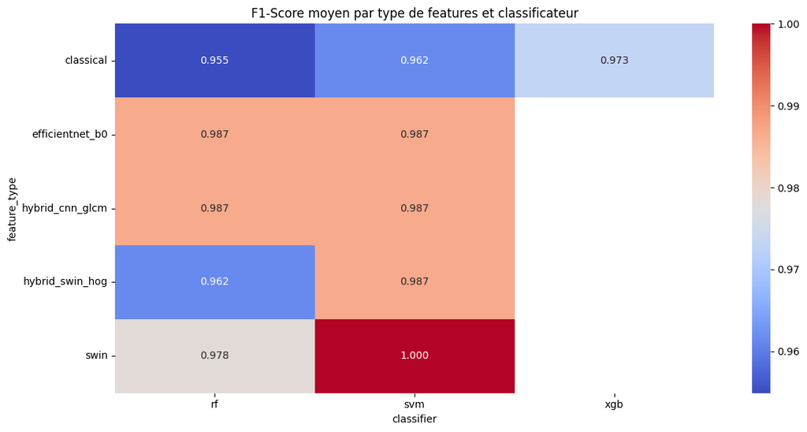

```python
results = []
feature_list = ['classical','efficientnet_b0','swin','hybrid_cnn_glcm','hybrid_swin_hog']
reduction_list = [None,'pca','ica','svd']

for feature in feature_list:
    for red in reduction_list:
        for clf_name in ['svm','rf']:
            if red is None or feature=='classical' or clf_name in ['svm','rf']:
                results.append(run_experiment(df_train, df_val, df_test, feature, red, n_components=128, classifier_name=clf_name))
if XGBOOST_AVAILABLE:
    results.append(run_experiment(df_train, df_val, df_test, 'classical', 'pca', classifier_name='xgb'))

# Tableau comparatif
df_results = pd.DataFrame([{k:v for k,v in r.items() if k!='confusion_matrix'} for r in results])
df_results = df_results.sort_values('f1_score', ascending=False).reset_index(drop=True)

# Heatmap F1-score
plt.figure(figsize=(12,6))
pivot = df_results.pivot_table(values='f1_score', index='feature_type', columns='classifier', aggfunc='mean')
sns.heatmap(pivot, annot=True, cmap='coolwarm', fmt=".3f")
plt.title("F1-Score moyen par type de features et classificateur")
plt.tight_layout()
plt.show()
```

Les performances sont évaluées à l’aide des métriques suivantes :

- Accuracy
- F1-score
- Recall par classe

[output not shown]

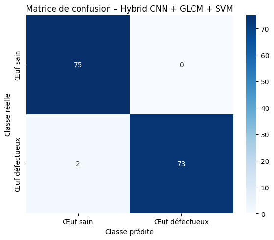

```python
best_result = next(
    r for r in results
    if r['feature_type'] == 'hybrid_cnn_glcm' and r['classifier'] == 'svm'
)

cm = best_result['confusion_matrix']

plt.figure(figsize=(6, 5))
sns.heatmap(
    cm,
    annot=True,
    fmt='d',
    cmap='Blues',
    xticklabels=['Œuf sain', 'Œuf défectueux'],
    yticklabels=['Œuf sain', 'Œuf défectueux']
)

plt.xlabel("Classe prédite")
plt.ylabel("Classe réelle")
plt.title("Matrice de confusion – Hybrid CNN + GLCM + SVM")
plt.tight_layout()
plt.show()
```

Cette matrice de confusion révèle un comportement asymétrique optimal pour notre application :

```
    •	Pas de faux positifs : économiquement avantageux (pas de gaspillage)
    •	Très peu de faux négatifs : risque sanitaire minimal (97.3% de détection)
```

### ENTRAÎNEMENT FINAL DU MEILLEUR MODELE

```python
X_final, y_final = extract_hybrid_cnn_glcm(df_train)
```

### SCALER FINAL

```python
scaler_final = StandardScaler()
X_final = scaler_final.fit_transform(X_final)
```

### REDUCTION FINALE

```python
pca_final = PCA(n_components=128, random_state=RANDOM_STATE)
X_final = pca_final.fit_transform(X_final)
```

### MODELE FINAL

```python
clf_final = SVC(
    kernel='rbf',
    probability=True,
    class_weight='balanced',
    random_state=RANDOM_STATE
)

# Entraînement
clf_final.fit(X_final, y_final)
```

```
SVC(class_weight='balanced', probability=True, random_state=42)
```

### CREATION DU PIPELINE

```python
# PRETRAITEMENT IMAGE
def preprocess_image_gray(img_path, target_size=(224, 224)):
    img = cv2.imread(img_path)
    if img is None:
        raise ValueError("Image non lisible")
    gray = cv2.cvtColor(img, cv2.COLOR_BGR2GRAY)
    gray = cv2.normalize(gray, None, 0, 255, cv2.NORM_MINMAX)
    gray = cv2.medianBlur(gray, 5)
    clahe = cv2.createCLAHE(2.0, (8, 8))
    gray = clahe.apply(gray)
    gray = cv2.resize(gray, target_size)
    return gray.astype(np.uint8)

# GLCM
def extract_glcm(img_gray):
    glcm = graycomatrix(
        img_gray,
        distances=[1, 2],
        angles=[0, np.pi/4, np.pi/2],
        levels=256,
        symmetric=True,
        normed=True
    )
    features = []
    for prop in ['contrast', 'homogeneity', 'energy', 'correlation']:
        features.extend(graycoprops(glcm, prop).ravel())
    return np.array(features)

# CNN (EfficientNet B0)
transform_imagenet = T.Compose([
    T.Resize((224,224)),
    T.ToTensor(),
    T.Normalize(
        mean=[0.485, 0.456, 0.406],
        std=[0.229, 0.224, 0.225]
    )
])

def load_cnn_model():
    model = models.efficientnet_b0(weights="IMAGENET1K_V1")
    model.classifier = torch.nn.Identity()
    model.eval().to(device)
    return model

cnn_model = load_cnn_model()

def extract_cnn_features(img_path):
    img = Image.open(img_path).convert("RGB")
    img_tensor = transform_imagenet(img).unsqueeze(0).to(device)
    with torch.no_grad():
        feat = cnn_model(img_tensor)
    return feat.cpu().squeeze().numpy()


# EXTRACTION HYBRIDE FINALE
def extract_hybrid_cnn_glcm_single(img_path):
    """
    EXACTEMENT la même extraction que pendant l'entraînement :
    - Prétraitements
    - CNN embeddings
    - GLCM
    - concaténation
    """
    img_gray = preprocess_image_gray(img_path)
    cnn_feat = extract_cnn_features(img_path)
    glcm_feat = extract_glcm(img_gray)
    features = np.concatenate([cnn_feat, glcm_feat])
    return features
```

Construction et sauvegarde du pipeline final

Une fois le meilleur modèle identifié à partir des expériences comparatives, il est nécessaire de regrouper l’ensemble des étapes de traitement dans un pipeline unique et cohérent.

Ce pipeline garantit que :

- les mêmes transformations appliquées lors de l’entraînement seront systématiquement reproduites lors de l’inférence ;
- le modèle peut être réutilisé sans dépendre du notebook d’origine ;
- le déploiement vers une API ou une application devient possible.

Le pipeline final intègre successivement :

1. la normalisation des caractéristiques par `StandardScaler`,
2. la réduction de dimension par Analyse en Composantes Principales (PCA),
3. le classificateur entraîné (SVM à noyau RBF).

Cette approche permet de sécuriser la chaîne de traitement et d’éviter toute incohérence entre les données d’entraînement et les données de test.

```python
import joblib
from sklearn.pipeline import Pipeline

pipeline_qualite_oeuf = Pipeline(steps=[
    ("scaler", scaler_final),
    ("reduction", pca_final),
    ("classifier", clf_final)
])

joblib.dump(pipeline_qualite_oeuf, "pipeline_qualite_oeuf.joblib")

print("Pipeline final créé et sauvegardé avec succès.")
```

```
Pipeline final créé et sauvegardé avec succès.
```

Sauvegarde du modèle entraîné

Afin de permettre la réutilisation du modèle en dehors de l’environnement d’entraînement, le pipeline complet est sauvegardé à l’aide de la bibliothèque `joblib`.

Cette sauvegarde inclut :

- les paramètres du scaler,
- les composantes principales du PCA,
- les poids du classificateur.

Le fichier généré constitue un artefact de production pouvant être chargé directement par une API ou une application utilisateur.

### TEST DU PIPELINE

```python
import joblib

# Chargement du pipeline entraîné
pipeline = joblib.load("pipeline_qualite_oeuf.joblib")

# Image de test
img_test_path = "C:\\Users\\cheic\\Pictures\\Screenshots\\3.png"

# Extraction EXACTE
X_test = extract_hybrid_cnn_glcm_single(img_test_path)
X_test = X_test.reshape(1, -1)

# Prédiction
prediction = pipeline.predict(X_test)
proba = pipeline.predict_proba(X_test)

print("Classe prédite :", "Œuf défectueux" if prediction[0] == 1 else "Œuf sain")
print("Probabilités :", proba)
```

```
Classe prédite : Œuf défectueux
Probabilités : [[0.16343285 0.83656715]]
```

## 10. Discussion et limites

Malgré les résultats satisfaisants obtenus, certaines limites doivent être soulignées. La qualité du modèle reste dépendante de la diversité du jeu de données, notamment en ce qui concerne les types de défauts représentés et les conditions d’éclairage. Certaines confusions observées dans la matrice de confusion peuvent être attribuées à des fissures très fines ou à des variations visuelles ambiguës.

Dans une perspective d’amélioration, plusieurs axes peuvent être envisagés :

- l’augmentation du jeu de données par des acquisitions réelles en environnement industriel ;
- l’optimisation des hyperparamètres des modèles profonds ;
- l’entraînement end-to-end d’un réseau dédié à la tâche ;
- l’intégration du pipeline dans une API ou une application interactive, permettant une utilisation en temps réel.

Ce travail constitue ainsi une base solide pour le développement d’un système automatisé d’inspection visuelle, avec un potentiel réel d’application dans un contexte industriel.

## Conclusion

Dans ce projet, nous avons développé un système complet de détection automatique de la qualité des œufs à partir d’images, en combinant des méthodes de vision par ordinateur classiques et des approches modernes basées sur le deep learning.

Le modèle retenu présente de bonnes performances en termes de F1-score et de capacité de détection des œufs défectueux, ce qui répond directement à l’objectif initial du projet. La structuration finale sous forme de pipeline assure la reproductibilité des résultats et ouvre la voie à une exploitation opérationnelle.